# COMPSCIX 415.2 Homework 5/Midterm

Rachel Hollowgrass

3/6/2018

```r
library(tidyverse)
```

# Git and Github (1.5 points)

[Github repository ‘rachelhollowgrass’](https://github.com/rachelhollowgrass/ids-hw-1/tree/master/Homework%205%20Midterm)

# The tidyverse packages (3 points)

**1. Can you name which package is associated with each task below?**

**Plotting:** `ggplot`

**Data munging/wrangling:** `dplyr`

**Reshaping (speading and gathering) data**: `tidyr`

**Importing/exporting data**: `readr`

**2. Now can you name two functions that you’ve used from each package that you listed above for these tasks?**

**Plotting:**

- `geom_point()`
- `geom_boxplot()`

**Data munging/wrangling:**

- `filter()`
- `arrange()`

**Reshaping data**:

- `gather()`
- `spread()`

**Importing/exporting data** *(note that readRDS and saveRDS are base R functions)*:

- `read_csv()`
- `write_tsv()`

# R Basics (1.5 points)

**1. Fix this code *with the fewest number of changes possible* so it works:**

The single change is to remove the exclamation point from the end of the variable name:

```r
# My_data.name___is.too00ooLong! <- c( 1 , 2   , 3 )
My_data.name___is.too00ooLong <- c( 1 , 2   , 3 )
```

**2. Fix this code so it works:**

**Changes:**

- Add a terminal single quote to the last item in the vector.
- Change the “C” to lower case.

```r
# my_string <- C('has', 'an', 'error', 'in', 'it)
my_string <- c('has', 'an', 'error', 'in', 'it')
```

**3. Look at the code below and comment on what happened to the values in the vector.**

**Comment:** I assumed that the first, second and last items would have remained integers, but they were converted to strings. In a quick test, I see that unless all vector items are initially numeric, they are all converted to stings.

```r
my_vector <- c(1, 2, '3', '4', 5)
my_vector
```

```
## [1] "1" "2" "3" "4" "5"
```

```r
all_numeric_vector <- c(1, 2, 3, 4, 5)
all_numeric_vector
```

```
## [1] 1 2 3 4 5
```

```r
all_but_one_numeric_vector <- c(1, 2, '3', 4, 5)
all_but_one_numeric_vector
```

```
## [1] "1" "2" "3" "4" "5"
```

# Data import/export (3 points)

**1. Download the rail_trail.txt file from Canvas (in the Midterm Exam section here) and successfully import it into R. Prove that it was imported successfully by including your import code and taking a glimpse of the result.**

```r
rail_trail_data <- read.csv('../data/rail_trail.txt', sep="|")
glimpse(rail_trail_data)
```

```
## Observations: 90
## Variables: 10
## $ hightemp   <int> 83, 73, 74, 95, 44, 69, 66, 66, 80, 79, 78, 65, 41,...
## $ lowtemp    <int> 50, 49, 52, 61, 52, 54, 39, 38, 55, 45, 55, 48, 49,...
## $ avgtemp    <dbl> 66.5, 61.0, 63.0, 78.0, 48.0, 61.5, 52.5, 52.0, 67....
## $ spring     <int> 0, 0, 1, 0, 1, 1, 1, 1, 0, 0, 0, 1, 1, 0, 0, 1, 0, ...
## $ summer     <int> 1, 1, 0, 1, 0, 0, 0, 0, 1, 1, 1, 0, 0, 0, 0, 0, 1, ...
## $ fall       <int> 0, 0, 0, 0, 0, 0, 0, 0, 0, 0, 0, 0, 0, 1, 1, 0, 0, ...
## $ cloudcover <dbl> 7.6, 6.3, 7.5, 2.6, 10.0, 6.6, 2.4, 0.0, 3.8, 4.1, ...
## $ precip     <dbl> 0.00, 0.29, 0.32, 0.00, 0.14, 0.02, 0.00, 0.00, 0.0...
## $ volume     <int> 501, 419, 397, 385, 200, 375, 417, 629, 533, 547, 4...
## $ weekday    <int> 1, 1, 1, 0, 1, 1, 1, 0, 0, 1, 1, 1, 1, 1, 1, 1, 0, ...
```

**2. Export the file into an R-specific format and name it “rail_trail.rds”. Make sure you define the path correctly so that you know where it gets saved. Then reload the file. Include your export and import code and take another glimpse.**

```r
rail_trail_data <- read.csv('../data/rail_trail.txt', sep="|")
saveRDS(rail_trail_data, file = "../data/rail_trail.rds")
rail_trail_as_rds <- readRDS('../data/rail_trail.rds')
glimpse(rail_trail_as_rds)
```

```
## Observations: 90
## Variables: 10
## $ hightemp   <int> 83, 73, 74, 95, 44, 69, 66, 66, 80, 79, 78, 65, 41,...
## $ lowtemp    <int> 50, 49, 52, 61, 52, 54, 39, 38, 55, 45, 55, 48, 49,...
## $ avgtemp    <dbl> 66.5, 61.0, 63.0, 78.0, 48.0, 61.5, 52.5, 52.0, 67....
## $ spring     <int> 0, 0, 1, 0, 1, 1, 1, 1, 0, 0, 0, 1, 1, 0, 0, 1, 0, ...
## $ summer     <int> 1, 1, 0, 1, 0, 0, 0, 0, 1, 1, 1, 0, 0, 0, 0, 0, 1, ...
## $ fall       <int> 0, 0, 0, 0, 0, 0, 0, 0, 0, 0, 0, 0, 0, 1, 1, 0, 0, ...
## $ cloudcover <dbl> 7.6, 6.3, 7.5, 2.6, 10.0, 6.6, 2.4, 0.0, 3.8, 4.1, ...
## $ precip     <dbl> 0.00, 0.29, 0.32, 0.00, 0.14, 0.02, 0.00, 0.00, 0.0...
## $ volume     <int> 501, 419, 397, 385, 200, 375, 417, 629, 533, 547, 4...
## $ weekday    <int> 1, 1, 1, 0, 1, 1, 1, 0, 0, 1, 1, 1, 1, 1, 1, 1, 0, ...
```

# Visualization (6 points)

**1. Critique the “Mrs. President” graphic: give only three examples of what is wrong with this graphic. Be concise.**

- **Proximity:** The circles in the left column are touching each other, which suggests that they are related, but they are at best of two types (age ranges, and gender) and not related as visually implied.
- **Size:** The promiment, varied sizes of the circles suggest that their size is important, but as circles the sizes are difficult to compare; however, casual observation suggests that the diameter of the circles more closely corresponds to the labeled values than their area.
- **Color:** Color is used to differentiate between genders and not ages. This seems like a random choice.

**2. Reproduce this graphic [horizontal box plot] using the diamonds data set.**

i was not fully able to reproduce the original graphic. It looks like superimposing a stacked floating bar plot over the carat value would be a good approach, but I did not see an clear way to do that.

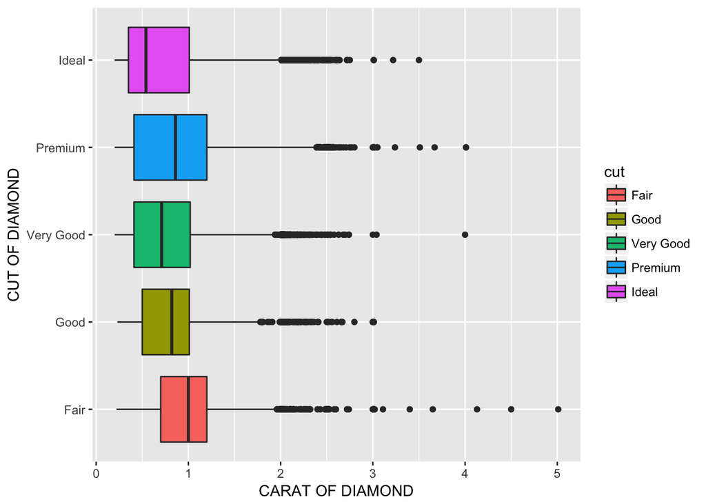

```r
ggplot(data = diamonds, mapping = aes(x = cut, y = carat, fill = cut)) +
  geom_boxplot() +
  labs(x = "CUT OF DIAMOND", y = "CARAT OF DIAMOND") +
  coord_flip()
```

**3. The previous graphic is not very useful. We can make it much more useful by changing one thing about it. Make the change and plot it again.**

The original graphic is not useful because it looks like the bars within the boxplots are hiding each other. By breaking out the `color` variable, it’s easier to see how the colors are distributed wihin each `cut`.

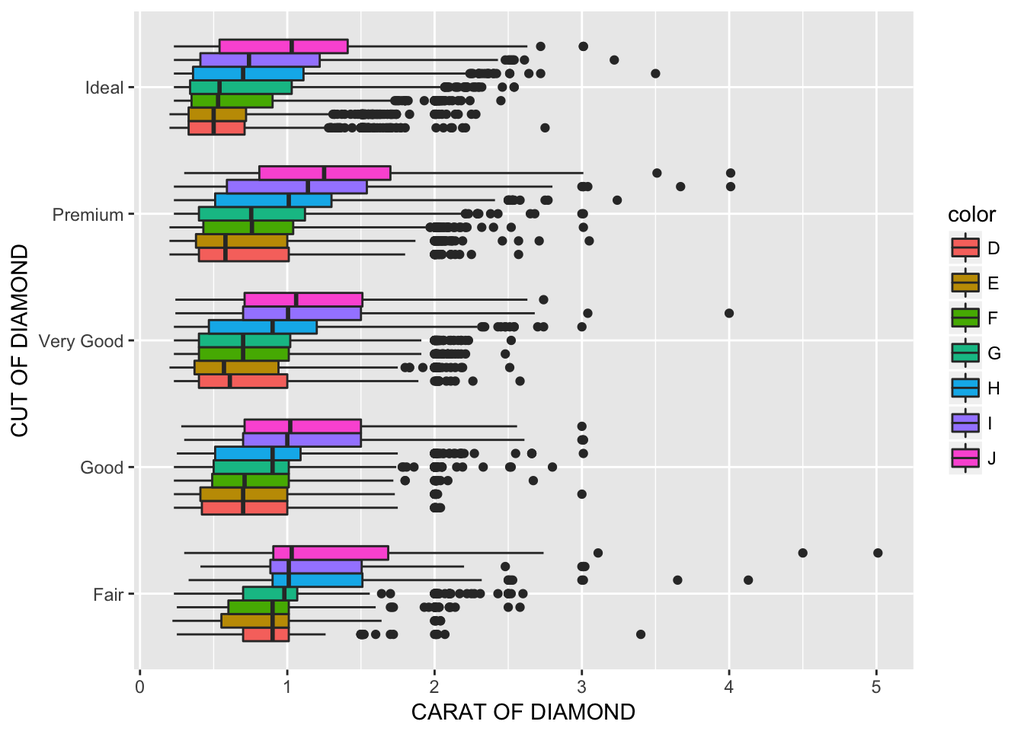

```r
ggplot(data = diamonds, mapping = aes(x = cut, y = carat, fill = color)) +
  geom_boxplot() +
  labs(x = "CUT OF DIAMOND", y = "CARAT OF DIAMOND") +
  coord_flip()
```

# Data munging and wrangling (6 points)

**1. Is this data “tidy”? If yes, leave it alone and go to the next problem. If no, make it tidy. Note: this data set is called table2 and is available in the tidyverse package. It should be ready for you to use after you’ve loaded the tidyverse package.**

No, the data is not tidy. There are two ‘type’ values (‘cases’ and ‘population’), each of which should be its own variable.

```r
tidy_table2 <- spread(table2, key = type, value = count)
tidy_table2
```

```
## # A tibble: 6 x 4
##   country      year  cases population
##   <chr>       <int>  <int>      <int>
## 1 Afghanistan  1999    745   19987071
## 2 Afghanistan  2000   2666   20595360
## 3 Brazil       1999  37737  172006362
## 4 Brazil       2000  80488  174504898
## 5 China        1999 212258 1272915272
## 6 China        2000 213766 1280428583
```

**2. Create a new column in the diamonds data set called price_per_carat that shows the price of each diamond per carat (hint: divide). Only show me the code, not the output.**

```
# Make a new column & variable for the price per carat.
diamond_prices <- select(diamonds, price, carat)
# Give the new variable the value of price divided by carats.
transmute(diamond_prices, price, carat, price_per_carat = price / carat)
```

**3. For each cut of diamond in the diamonds data set, how many diamonds, and what proportion, have a price > 10000 and a carat < 1.5? There are several ways to get to an answer, but your solution must use the data wrangling verbs from the tidyverse in order to get credit.**

There are 834/53940 diamonds that meet these criteria:

- `price > 10000`
- `carat < 1.5`

The proportion is 1.5% of the total.

```r
diamonds_filtered <- filter(diamonds, price > 10000, carat < 1.5) %>% select(price, carat) %>% arrange(order(price))
proportion <- count(diamonds_filtered) / count(diamonds)
count(diamonds_filtered)
```

```
## # A tibble: 1 x 1
##       n
##   <int>
## 1   834
```

```r
count(diamonds)
```

```
## # A tibble: 1 x 1
##       n
##   <int>
## 1 53940
```

```r
proportion
```

```
##            n
## 1 0.01546162
```

- **Do the results make sense? Why?**

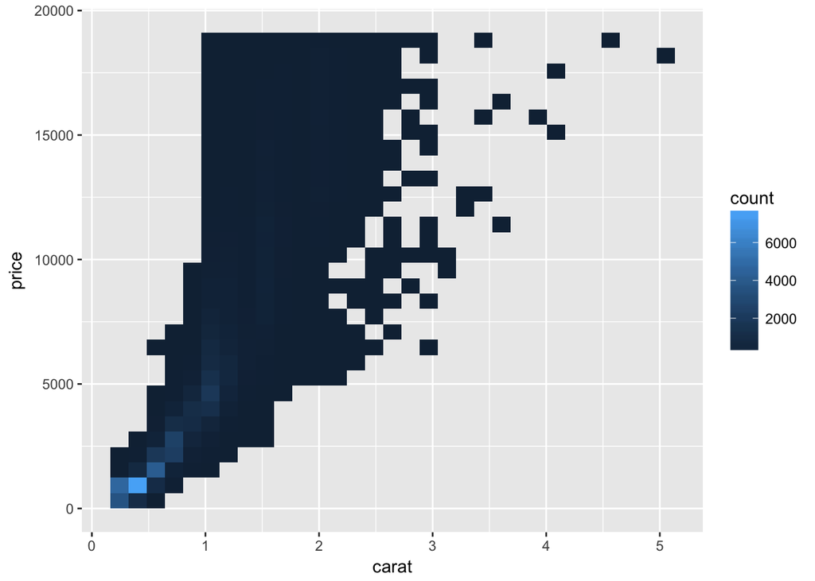

```r
ggplot(data = diamonds, mapping = aes(x = carat, y = price)) +
  geom_bin2d()
```

- **Do we need to be wary of any of these numbers? Why?**

The data may be incomplete; that is, some diamonds priced at over $10,000 may not have carat values, and vice versa. Also, the price of diamonds is not only related to their weight but also their cut, color, etc.

# EDA (6 points)

Take a look at the `txhousing` data set that is included with the `ggplot2` package and answer these questions:

**1. During what time period is this data from?**

The data in the `txhousing` data set is from the years 2000 to 2015.

**2. How many cities are represented?**

There are 46 cities represented.

```r
tx_cities <- txhousing
tx_cities %>%
  group_by(city) %>%
  summarize(count = n())
```

```
## # A tibble: 46 x 2
##    city                  count
##    <chr>                 <int>
##  1 Abilene                 187
##  2 Amarillo                187
##  3 Arlington               187
##  4 Austin                  187
##  5 Bay Area                187
##  6 Beaumont                187
##  7 Brazoria County         187
##  8 Brownsville             187
##  9 Bryan-College Station   187
## 10 Collin County           187
## # ... with 36 more rows
```

**3. Which city, month and year had the highest number of sales?**

Combined:

- In July 2015, Houston had the most sales for any city for any month in any year.

```r
tx_city_sales <- txhousing
tx_city_sales %>%
  group_by(city) %>%
  summarize(total_sales = sum(sales)) %>%
  arrange(desc(total_sales))
```

```
## # A tibble: 46 x 2
##    city              total_sales
##    <chr>                   <dbl>
##  1 Houston               1043999
##  2 Dallas                 816122
##  3 Austin                 373381
##  4 San Antonio            322097
##  5 Collin County          202892
##  6 Fort Bend              153088
##  7 Fort Worth             144791
##  8 NE Tarrant County      128007
##  9 Denton County          117405
## 10 Montgomery County      104589
## # ... with 36 more rows
```

```r
tx_month_sales <- txhousing
tx_month_sales %>%
  group_by(month) %>%
  summarize(total_sales = sum(month)) %>%
  arrange(desc(total_sales))
```

```
## # A tibble: 12 x 2
##    month total_sales
##    <int>       <int>
##  1    12        8280
##  2    11        7590
##  3    10        6900
##  4     9        6210
##  5     8        5520
##  6     7        5152
##  7     6        4416
##  8     5        3680
##  9     4        2944
## 10     3        2208
## 11     2        1472
## 12     1         736
```

```r
tx_year_sales <- txhousing
tx_year_sales %>%
  group_by(year) %>%
  summarize(total_sales = sum(year)) %>%
  arrange(desc(total_sales))
```

```
## # A tibble: 16 x 2
##     year total_sales
##    <int>       <int>
##  1  2014     1111728
##  2  2013     1111176
##  3  2012     1110624
##  4  2011     1110072
##  5  2010     1109520
##  6  2009     1108968
##  7  2008     1108416
##  8  2007     1107864
##  9  2006     1107312
## 10  2005     1106760
## 11  2004     1106208
## 12  2003     1105656
## 13  2002     1105104
## 14  2001     1104552
## 15  2000     1104000
## 16  2015      648830
```

```r
tx_criteria_sales <- txhousing
tx_criteria_sales %>%
  group_by(city,year,month) %>%
  summarize(total_sales = sum(sales)) %>%
  arrange(desc(total_sales))
```

```
## # A tibble: 8,602 x 4
## # Groups:   city, year [736]
##    city     year month total_sales
##    <chr>   <int> <int>       <dbl>
##  1 Houston  2015     7        8945
##  2 Houston  2006     6        8628
##  3 Houston  2013     7        8468
##  4 Houston  2015     6        8449
##  5 Houston  2013     5        8439
##  6 Houston  2014     6        8391
##  7 Houston  2014     7        8391
##  8 Houston  2014     8        8167
##  9 Houston  2013     8        8155
## 10 Houston  2006     5        8040
## # ... with 8,592 more rows
```

**4. What kind of relationship do you think exists between the number of listings and the number of sales? Check your assumption and show your work.**

Unless there are extreme forces at work, I would expect listings to reflect demand, with a similar ratio of sales to listings each month.  
This turned out not to be true at all. After including the ratio between the two, I don’t see any simple pattern.

```r
sales_to_listings <- txhousing
sales_to_listings %>% group_by(year, month) %>% select(year, month, listings, sales)
```

```
## # A tibble: 8,602 x 4
## # Groups:   year, month [187]
##     year month listings sales
##    <int> <int>    <dbl> <dbl>
##  1  2000     1      701  72.0
##  2  2000     2      746  98.0
##  3  2000     3      784 130
##  4  2000     4      785  98.0
##  5  2000     5      794 141
##  6  2000     6      780 156
##  7  2000     7      742 152
##  8  2000     8      765 131
##  9  2000     9      771 104
## 10  2000    10      764 101
## # ... with 8,592 more rows
```

```r
transmute(sales_to_listings, year, month, listings, sales, ratio = sales / listings) %>% arrange(order(ratio))
```

```
## # A tibble: 8,602 x 5
##     year month listings  sales   ratio
##    <int> <int>    <dbl>  <dbl>   <dbl>
##  1  2001     7      504   43.0  0.0853
##  2  2001    11     3213  381    0.119
##  3  2005     7      833  145    0.174
##  4  2009    10    22128 4150    0.188
##  5  2012    11     1360  154    0.113
##  6  2014    10      454   60.0  0.132
##  7  2010     6     2156  156    0.0724
##  8  2009     3      618   37.0  0.0599
##  9  2014     5     4100  519    0.127
## 10  2005     4       NA  547   NA
## # ... with 8,592 more rows
```

**5. What proportion of sales is missing for each city?**

The proportion of “sales is missing for each city” is the number of missing sales entries per city divided by the total number of rows for that city. It turns out that all cities have the same number of `sale_entries_per_city`: 187.

Dividing the number of `missing_sales` by `entries_per_city` yields the `proportion_of_missing_sales`.

```r
# First, find out how many sales entries there are per city.
housing_by_city <-
txhousing %>%
  group_by(city) %>%
  summarize(sale_entries_per_city = n())

housing_by_city
```

```
## # A tibble: 46 x 2
##    city                  sale_entries_per_city
##    <chr>                                 <int>
##  1 Abilene                                 187
##  2 Amarillo                                187
##  3 Arlington                               187
##  4 Austin                                  187
##  5 Bay Area                                187
##  6 Beaumont                                187
##  7 Brazoria County                         187
##  8 Brownsville                             187
##  9 Bryan-College Station                   187
## 10 Collin County                           187
## # ... with 36 more rows
```

```r
entries_per_city <- as.numeric(housing_by_city[1, "sale_entries_per_city"])

# Next, take the sale_entries_per_city value from above (187) and divide the number of missing values by it.
txhousing %>%
  group_by(city) %>%
  filter(is.na(sales)) %>%
  summarize(missing_sales = n(), proportion_of_missing_sales = n() / entries_per_city)
```

```
## # A tibble: 20 x 3
##    city               missing_sales proportion_of_missing_sales
##    <chr>                      <int>                       <dbl>
##  1 Brazoria County               14                     0.0749
##  2 Brownsville                    2                     0.0107
##  3 Corpus Christi                 1                     0.00535
##  4 Galveston                      1                     0.00535
##  5 Harlingen                     25                     0.134
##  6 Kerrville                    104                     0.556
##  7 Killeen-Fort Hood              1                     0.00535
##  8 Laredo                        36                     0.193
##  9 Longview-Marshall             12                     0.0642
## 10 Lubbock                        1                     0.00535
## 11 McAllen                        2                     0.0107
## 12 Midland                       75                     0.401
## 13 Nacogdoches                   11                     0.0588
## 14 Odessa                        72                     0.385
## 15 Port Arthur                    2                     0.0107
## 16 San Marcos                    46                     0.246
## 17 South Padre Island           116                     0.620
## 18 Temple-Belton                 11                     0.0588
## 19 Texarkana                     17                     0.0909
## 20 Waco                          19                     0.102
```

**6. Looking at only the cities and months with greater than 500 sales:**

```r
sales_over_500 <- group_by(txhousing, city, year, month) %>%
  filter(sales > 500) %>% select(city, year, month, sales) %>%
  arrange(desc(sales))
sales_over_500
```

```
## # A tibble: 1,883 x 4
## # Groups:   city, year, month [1,883]
##    city     year month sales
##    <chr>   <int> <int> <dbl>
##  1 Houston  2015     7  8945
##  2 Houston  2006     6  8628
##  3 Houston  2013     7  8468
##  4 Houston  2015     6  8449
##  5 Houston  2013     5  8439
##  6 Houston  2014     6  8391
##  7 Houston  2014     7  8391
##  8 Houston  2014     8  8167
##  9 Houston  2013     8  8155
## 10 Houston  2006     5  8040
## # ... with 1,873 more rows
```

- **Are the distributions of the median sales price (column name median), when grouped by city, different? The same? Show your work.**

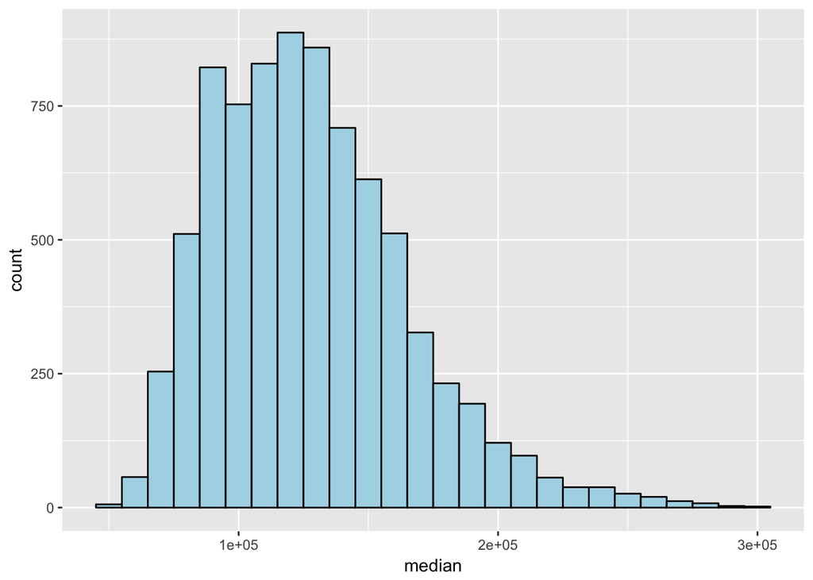

```r
median_not_na <- filter(txhousing, !(is.na(median)))

ggplot(median_not_na, aes(x = median)) +
  geom_histogram(fill='lightblue', color='black', binwidth=10000)
```

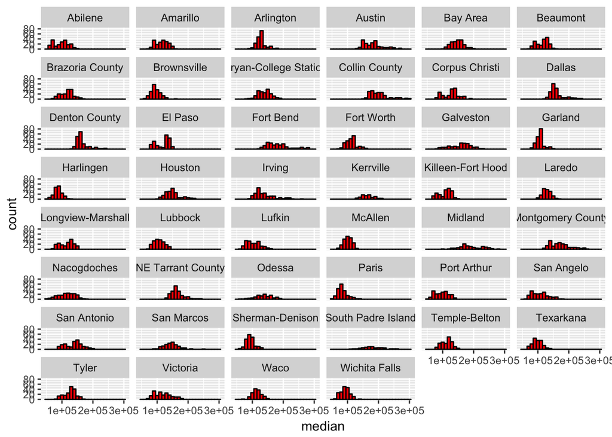

```r
ggplot(median_not_na, aes(x = median)) +
  geom_histogram(fill='red', color='black', binwidth=10000) +
  facet_wrap(~ city, nrow = 8)
```

- **Any cities that stand out that you’d want to investigate further?**

Abeline, El Paso , Longview-Marshall and San Antonio appear to have overlapping curves (two humps). I wonder what might be causing that, though it might be an effect of the bin width.

- **Why might we want to filter out all cities and months with sales less than 500?**

When there are fewer than a certain number of sales, the statistics on those sales become less meaningful. For a large real estate company, 500 might be a good threshold to use. For someone wanting to know how likely they could buy a house, the threshold could be lower.